# Tutorial 3

[Aurel Mélard](https://sites.google.com/view/aurel-melard)

aurel.melard@polytechnique.edu

CREST - Institut Polytechnique de Paris - IPP

March 11, 2026

## Roadmap

**Note**

Disclaimer: the recap on OLS is inspired by Sciences Po’s Introduction to Econometrics with R. Interested students can check the full material [here](https://scpoecon.github.io/ScPoEconometrics/).

## Recap on linear regression

### Visual intuition

1. Assess the statistical relationship between variables (not necessarily causal)
2. In the toolbox of the social scientist, with many other empirical tools

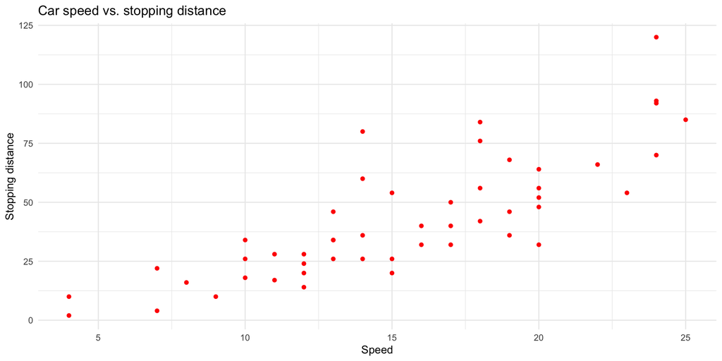

```r
ggplot(cars,aes(x=speed,y=dist)) +
  geom_point(color="red") +
  labs(x ="Speed", y = "Stopping distance", title = "Car speed vs. stopping distance")+
  theme_minimal()
```

It seems that there is a linear relationship between these two variables

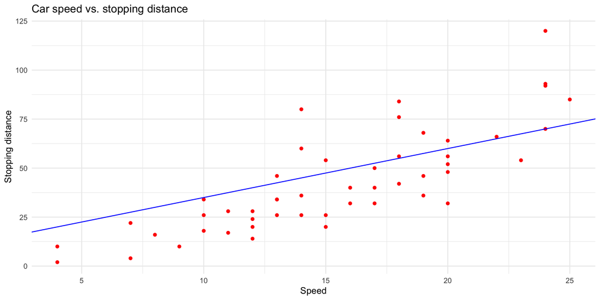

```r
ggplot(cars,aes(x=speed,y=dist)) +
  geom_point(color="red") +
  geom_abline(intercept=10,slope=2.5,color="blue") +
  labs(x ="Speed", y = "Stopping distance", title = "Car speed vs. stopping distance")+
  theme_minimal()
```

There are a priori many ways to have a better “fit” (smaller distance between observed and predicted distances)

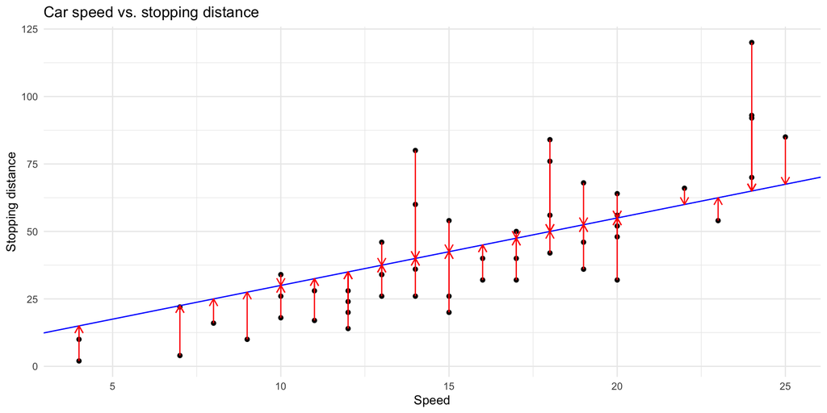

```r
ggplot(cars, aes(x = speed, y = dist)) +
  geom_point(color = "black") +
  geom_abline(intercept = 5, slope = 2.5, color = "blue") +
  geom_segment(aes(x = speed,
                   y = dist,
                   xend = speed,
                   yend = 5 + 2.5 * speed),
               arrow = arrow(length = unit(0.1, "inches")),
               color = "red") +
  labs(x ="Speed", y = "Stopping distance", title = "Car speed vs. stopping distance")+
  theme_minimal()
```

### OLS estimator

- Minimizes the sum of squared distances ($\sim$ error), thus the name “ordinary least square”
- An affine function is defined as $y = \beta_0 + \beta_1 x$ which in matrix form gives $Y = X\beta$.
- Dimension of $X$?
- The error for each observation is $\epsilon_i = y_i - \beta_0 - \beta_1 x_i$
- Hence, we look for $\hat{\beta}$ to minimize:
  $$\min_\beta (Y - X\beta)'(Y - X\beta) = \min_\beta \epsilon'\epsilon$$
- The OLS estimator is then:
  $$\hat{\beta} = (X'X)^{-1}X'y$$
- **Question**: Derive $\hat{\beta}$ from the problem’s first order condition

### Gauss-Markov

Under the following assumptions:

- 1. Linearity of the “true” model $y = x'\beta + \epsilon$
- 2. Observed sample $(y_i,x_i)_{i= 1...n}$ is a random sample with the same distribution as $(y,x)$
- 3. No perfect collinearity between the covariates in the sample (and in the population)
- 4. Zero conditional mean $E(\epsilon|x) =0$
- 5. Homoskedasticity $Var(\epsilon|x_1,...,x_n) = \sigma^2$

The OLS estimator is BLUE: best linear unbiased estimator

- Linear estimator: $\hat{\beta}_j = \sum\limits_1^n w_{ij} y_i$, $w_{ij}$ functions of $x_1,...x_n$
- Unbiased: $E(\hat{\beta}|x_1,...,x_n) = \beta$
- “Best”: smallest variance of all linear unbiased estimators, conditional on observed $x_1,...x_n$

**Tip**

Only Assumptions 1-4 are needed for unbiasedness

### Failures of assumptions: linearity

Francis Anscombe created four datasets with identical linear statistics: mean, variance, correlation and regression line are identical. Their data generating processes are however very different

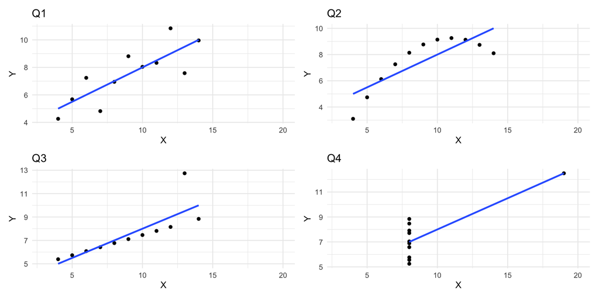

### Failures of assumptions: endogeneity

Assumption **4** might not hold for various reasons:

- 1. Measurement error: We measure $\tilde{x} = x +u$ instead of $x$. Example?
- 2. Omitted variable in the model correlated with $x$. Example?
- 3. Simultaneity: $x$ and $y$ are determined simulatenously and endogenously. Example?

In all these cases, we might have $E(X|\epsilon) \neq 0$ and a biased estimator $E(\hat{\beta}) \neq \beta$.

### Omitted variable bias

Consider the true model: $Y = \beta_0 + \beta_1 X_1 + \beta_2 X_2 + \epsilon$, $E[\epsilon | X_1, X_2] = 0$. Suppose $X_2$ is omitted from the regression. The estimated model is:

$$Y = \alpha_0 + \alpha_1 X_1 + u$$

where the new error term $u$ is: $u = \beta_2 X_2 + \epsilon$. Since $X_2$ is omitted, we express it in terms of $X_1$ using the linear projection:

$$X_2 = \gamma_0 + \gamma_1 X_1 + v$$

where $v$ is the residual such that $E[v | X_1] = 0$. Substituting into the true model:

$$u = \beta_2 \gamma_0 + \beta_2 \gamma_1 X_1 + \beta_2 v + \epsilon$$

Since $u$ is correlated with $X_1$, the OLS estimator for $\alpha_1$ is defined by:

$$\hat{\alpha}_1 = \frac{Cov(Y, X_1)}{Var(X_1)}$$

Substituting $Y$ from the true model:

$$\hat{\alpha}_1 = \frac{Cov(\beta_0 + \beta_1 X_1 + \beta_2 X_2 + \epsilon, X_1)}{Var(X_1)}$$

Expanding covariance terms:

$$\hat{\alpha}_1 = \beta_1 + \beta_2 \frac{Cov(X_2, X_1)}{Var(X_1)}$$

Using the projection equation:

$$\hat{\alpha}_1 = \beta_1 + \beta_2 \gamma_1$$

Since $\gamma_1 \neq 0$ if $X_1$ and $X_2$ are correlated, and $\beta_2 \neq 0$ if $X_2$ is relevant, it follows that:

$$E[\hat{\alpha}_1] \neq \beta_1$$

## Example of OLS regression in R

### lm function

The main R function for OLS regression is `lm`. For linear model, the syntax is `lm(y ~ x)`. It yields

```r
summary(lm(cars$dist ~ cars$speed))
```

```
Call:
lm(formula = cars$dist ~ cars$speed)

Residuals:
    Min      1Q  Median      3Q     Max
-29.069  -9.525  -2.272   9.215  43.201

Coefficients:
            Estimate Std. Error t value Pr(>|t|)
(Intercept) -17.5791     6.7584  -2.601   0.0123 *
cars$speed    3.9324     0.4155   9.464 1.49e-12 ***
---
Signif. codes:  0 '***' 0.001 '**' 0.01 '*' 0.05 '.' 0.1 ' ' 1

Residual standard error: 15.38 on 48 degrees of freedom
Multiple R-squared:  0.6511,    Adjusted R-squared:  0.6438
F-statistic: 89.57 on 1 and 48 DF,  p-value: 1.49e-12
```

- Summary statistics on the residuals
- Estimated parameters, their standard errors and **t-value**
- R-squared

### P-value and hypothesis testing

Assuming Gauss-Markov assumptions hold, the OLS estimator has the following Normal distribution:

$$\frac{\hat{\beta}-\beta}{\sqrt{\sigma^2 (X' X)^{-1}}} \tilde{} N\left(0, 1\right)$$

- Unfortunately, we will never know $\sigma^2$, the variance of the error term. Instead we have the empirical estimator of this t-statistic.

$$\hat{t} = \frac{\hat{\beta}-\beta}{se(\hat{\beta})} \tilde{} t(N−k)$$

- It can be showed that this statistic follows a Student law at $N-k$ degrees of freedom, with cumulative distribution $F$, where $N$ is the number of observations and $k$ the number of covariates.
- For very large $N$, this distribution is very close to the standard normal distribution.
- A standard hypothesis to test for the significance of estimated parameters is $H_0: \beta_k = 0$.
- The summary of the lm function yields the t-stat $t$ assuming $\beta_k =0$.
- Assuming this value holds, the t-statistics random variable T should follow a Student law at $N-k$ degrees of freedom.
- $H_0$ can be rejected with 95% confidence if the estimated parameter is “far enough” from zero, that is if the pvalue of the t stat verifies:

$$p_{value}(\hat{t}) = p((T < -|\hat{t}|)\cup(T > |\hat{t}|))) = 2p(T>|\hat{t}|) < 0.05 \Leftrightarrow 2p(T>|\hat{t}|) < 0.05$$

$$\Leftrightarrow \hat{t} = \left|\frac{\hat{\beta_k}-0}{se(\hat{\beta_k})}\right| > F^{-1}(1- 0.05/2) \approx 1.96$$

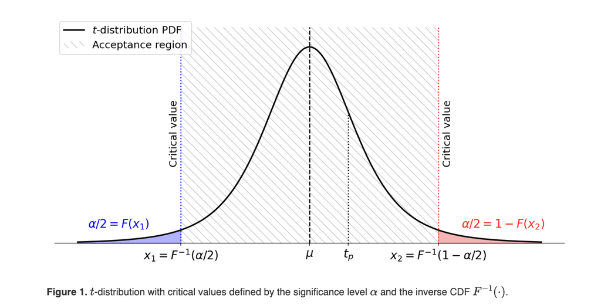

### R-squared

The sample variance of $y$ (SST - sum of squares total) can be decomposed into the explained (SSR - sum of squares regression) and residual variances (SSE - sum of squares errors):

$$\frac{1}{n-1}\sum\limits_{i=1}^n (y_i-\overline{y})^2 = \frac{1}{n-1}\sum\limits_{i=1}^n (\hat{y}_i-\overline{y})^2 + \frac{1}{n-1}\sum\limits_{i=1}^n (\hat{u}_i)^2$$

The R-squared is the share of the variance explained by the model:
$$R^2 = \frac{SSR}{SST} = 1- \frac{SSE }{ SST}$$

**Tip**

Proof comes from expanding

$$(y_i- \overline{y} )^2 = ((y_i- \hat{y}_i)+(\hat{y}_i - \overline{y}))^2$$

Noticing $y_i-\hat{y}_i= \hat{u}_i$, And $\hat{y}_i -\overline{y} = \hat{\beta}_1(x_i - \overline{x})$.

### The model

Recall that the Solow model assumes the following GDP production function:
$$Y(t) = K(t)^{\alpha} (L(t)A(t))^{1-\alpha}, 0<\alpha<1$$

In continuous time, exogenous and constant population and technology growth can be modelled by:

$$L(t) = L(0)e^{nt}$$

$$A(t) = A(0)e^{gt}$$

### Log-linearization

Recall from the class that output per effective unit reaches a steady state:

$$\frac{Y_t}{A_tL_t} = \left(\frac{s}{n+g+\delta}\right)^{\frac{\alpha}{1-\alpha}}$$

**Main issue** for empirical estimation: the model is not linear. However, taking the logs yields:

$$\ln\left(\frac{Y_t}{L_t}\right) = \ln(A_t) + \frac{\alpha}{1-\alpha} \ln(s) - \frac{\alpha}{1-\alpha} \ln(n+g+\delta)$$

The authors write as $\ln(A_t) = \ln(A(0))+ gt = a + gt + \epsilon$, where $\epsilon$ is a “country-specific shock”, which allows for OLS estimation:

$$\ln\left(\frac{Y_t}{L_t}\right) = \beta_0 + \beta_1 \ln(s) + \beta_2 \ln(n+g+\delta) +\epsilon$$

**Tip**

Strong assumptions for estimation: $n$ and $s$ independent of $\epsilon$. $g+\delta =0.05$ whatever the country. Discuss…

### Loading, describing, cleaning the data

- 1. Download the “MRW_QJE1992” data from Moodle. Load it in R, as well as usual packages.
- 2. Describe the data. Check that the three country groups “n”, “i”, “o” are nested
- 3. Compute summary statistics by group for the GDP growth and GDP per capita in 1985. How do countries differ across groups? The paper performs separate analysis for each group. Why?
- 4. Restrict the sample to non-missing groups. Build useful variables for the OLS regression.
- 5. Plot log of GDP per capita vs growth rate of GDP, log saving rate. What do you think of an analysis restricting the sample to group “o”?

### Estimates and interpretation

- 6. Run the model on the full sample and on each sub-group using “lm”. Store the results in appropriate objects.
- 7. Interpret the results in the light of the Solow model predictions. What is the share of cross-country income per capita variation is explained by the model?
- 8. In previous work, the share of capital in production was thought to be roughly 1/3, is this prediction supported by the data?
- 9. [Bonus] We assumed that $\beta_2 = - \beta_1$. The Fisher test allows to test if we can reject this hypothesis, using linearHypothesis() from the package car.
- 10. Discuss the specification: what reasons would Assumption 4 not hold?

### Augmented model

Mankiw et al. focuses on an **omitted variable** of the baseline Solow model: human capital (half of total capital in the US in 1976). The authors assume an alternative production function:

$$Y(t) = K(t)^{\alpha}H(t)^\beta (L(t)A(t))^{1-\alpha-\beta}, 0<\alpha + \beta<1$$

Human capital accumulates in the same way (same cost of one unit of consumption) at saving rate $s_h$ and depreciates at same rate $\delta$. That implies at the steady state per effective unit:

$$k^* = \left(\frac{s_k^{1-\beta} s_h^\beta}{n+g+\delta}\right)^{\frac{1}{1-\alpha - \beta}}$$

$$h^* = \left(\frac{s_k^\alpha s_h^{1-\alpha}}{n+g+\delta}\right)^{\frac{1}{1-\alpha - \beta}}$$

And after log linearizing output per effective unit (show it!):

$$\ln\left(\frac{Y_t}{L_t}\right) = \ln(A_0)+gt + \frac{\alpha}{1-\alpha-\beta} \ln(s_k) - \frac{\alpha+\beta}{1-\alpha-\beta} \ln(n+g+\delta) +\frac{\beta}{1-\alpha-\beta} \ln(s_h)$$

- 11. In the empirical specification, $s_h$ is the share of the working age population enrolled in education. Why?
- 12. Run the augmented regression. Interpret the coefficients and implied $\alpha$, $\beta$.
- 13. From what we have seen before on omitted variable bias, and the previous biased results, what do you think is the sign of $cov(s_h,s_k)$?
- 14. Export the results in latex using stargazer, and into a pdf using Overleaf